# INFO6105_FinalProject

# **📘 Introduction**

### **Context & Motivation**

- GitHub is one of the most widely used platforms for software development, open-source collaboration, and community-driven innovation.
- “Engagement” on GitHub — measured through watchers, stars, forks, and activity — serves as a key signal of visibility, user interest, and long-term project sustainability.
- Understanding **what drives engagement** is useful for developers, maintainers, and organizations aiming to build successful repositories.

### **Analytical Goal**

- The central goal of this project is to quantify how repository characteristics relate to engagement levels across GitHub projects.
- Specifically, the project aims to identify:
  - Which **numerical features** (stars, forks, age) most strongly predict engagement.
  - Whether **programming language** contributes to systematic differences in engagement.
  - Whether **language and popularity interact** — i.e., does language matter *more* for popular repositories?

### **Summary of Approach**

  - A Kaggle dataset of **215,029 GitHub repositories** was cleaned and processed.
  - A random sample of **500 repositories** was used to perform formal statistical modeling.
  - Three analyses were carried out:
    1. **Multiple Linear Regression** — to quantify predictors of engagement.
    2. **One-Way ANOVA** — to test differences in engagement by language.
    3. **Two-Way ANOVA** — to test language, popularity, and interaction effects.
  - Results contribute to a clearer understanding of what drives community interest on GitHub.

# **Step 1: Import Libraries**

```r
library(tidyverse)
library(janitor)
library(knitr)
library(broom)
library(car)
library(ggpubr)

data <- read_csv("Data/rgithub_repos.csv")
data <- clean_names(data)
glimpse(data)
```

```
## Rows: 215,029
## Columns: 24
## $ name            <chr> "freeCodeCamp", "free-programming-books", "awesome", "…
## $ description     <chr> "freeCodeCamp.org's open-source codebase and curriculu…
## $ url             <chr> "https://github.com/freeCodeCamp/freeCodeCamp", "https…
## $ created_at      <dttm> 2014-12-24 17:49:19, 2013-10-11 06:50:37, 2014-07-11 …
## $ updated_at      <dttm> 2023-09-21 11:32:33, 2023-09-21 11:09:25, 2023-09-21 …
## $ homepage        <chr> "http://contribute.freecodecamp.org/", "https://ebookf…
## $ size            <dbl> 387451, 17087, 1441, 187799, 20998, 5088, 2267461, 111…
## $ stars           <dbl> 374074, 298393, 269997, 267901, 265161, 256615, 251416…
## $ forks           <dbl> 33599, 57194, 26485, 21497, 69434, 29254, 34927, 40474…
## $ issues          <dbl> 248, 46, 61, 16712, 56, 191, 643, 393, 282, 1497, 649,…
## $ watchers        <dbl> 374074, 298393, 269997, 267901, 265161, 256615, 251416…
## $ language        <chr> "TypeScript", NA, NA, NA, NA, "Python", "TypeScript", …
## $ license         <chr> "BSD-3-Clause", "CC-BY-4.0", "CC0-1.0", "NOASSERTION",…
## $ topics          <chr> "['careers', 'certification', 'community', 'curriculum…
## $ has_issues      <lgl> TRUE, TRUE, TRUE, FALSE, TRUE, TRUE, TRUE, TRUE, TRUE,…
## $ has_projects    <lgl> TRUE, FALSE, FALSE, FALSE, FALSE, FALSE, FALSE, TRUE, …
## $ has_downloads   <lgl> TRUE, TRUE, TRUE, TRUE, TRUE, TRUE, TRUE, TRUE, TRUE, …
## $ has_wiki        <lgl> FALSE, FALSE, FALSE, FALSE, FALSE, FALSE, TRUE, TRUE, …
## $ has_pages       <lgl> TRUE, TRUE, TRUE, FALSE, FALSE, FALSE, TRUE, FALSE, FA…
## $ has_discussions <lgl> FALSE, FALSE, FALSE, FALSE, FALSE, FALSE, FALSE, FALSE…
## $ is_fork         <lgl> FALSE, FALSE, FALSE, FALSE, FALSE, FALSE, FALSE, FALSE…
## $ is_archived     <lgl> FALSE, FALSE, FALSE, TRUE, FALSE, FALSE, FALSE, FALSE,…
## $ is_template     <lgl> FALSE, FALSE, FALSE, FALSE, FALSE, FALSE, FALSE, FALSE…
## $ default_branch  <chr> "main", "main", "main", "master", "main", "master", "m…
```

# **Step 2: Data Cleaning + Feature Engineering**

```r
## ---- data_cleaning, message=FALSE, warning=FALSE ----

# Remove duplicated rows if they exist
data <- data %>% distinct()

# Convert character columns to factors where appropriate
data$language <- as.factor(data$language)
data$license <- as.factor(data$license)
data$default_branch <- as.factor(data$default_branch)

# Convert logical columns to numeric (TRUE=1, FALSE=0)
logical_cols <- sapply(data, is.logical)
data[logical_cols] <- lapply(data[logical_cols], as.numeric)

# Create repo age in years
data$created_at <- as.POSIXct(data$created_at, format="%Y-%m-%dT%H:%M:%S")
data$updated_at <- as.POSIXct(data$updated_at, format="%Y-%m-%dT%H:%M:%S")
data$repo_age_years <- as.numeric(difftime(Sys.time(), data$created_at, units = "days"))/365

# Replace missing values in numeric columns with median
num_cols <- sapply(data, is.numeric)
data[num_cols] <- lapply(data[num_cols], function(x){
  x[is.na(x)] <- median(x, na.rm=TRUE)
  x
})

# Replace missing language values with "Unknown"
data$language <- fct_explicit_na(data$language, na_level = "Unknown")
# Create language groups for ANOVA
data$language_group <- ifelse(data$language %in% c("Python", "JavaScript", "TypeScript"),
                              as.character(data$language),
                              "Other") %>%
  factor()

# Create popularity groups for t-test & regression
median_stars <- median(data$stars, na.rm=TRUE)
data$popularity_group <- ifelse(data$stars > median_stars, "High Stars", "Low Stars") %>%
  factor()

# Sample 500 rows for analysis
set.seed(6105)
sample_data <- data %>% sample_n(500)

glimpse(sample_data)
```

```
## Rows: 500
## Columns: 27
## $ name             <chr> "hostctl", "mobx-react-devtools", "URLEmbeddedView", …
## $ description      <chr> "Your dev tool to manage /etc/hosts like a pro!", "[D…
## $ url              <chr> "https://github.com/guumaster/hostctl", "https://gith…
## $ created_at       <dttm> 2020-03-14 11:29:02, 2015-08-29 19:53:39, 2016-03-06…
## $ updated_at       <dttm> 2023-09-25 13:06:30, 2023-09-18 05:51:45, 2023-09-02…
## $ homepage         <chr> "http://guumaster.github.io/hostctl", NA, NA, NA, "ht…
## $ size             <dbl> 3616, 753, 7840, 545, 38898, 25452, 3160, 16747, 162,…
## $ stars            <dbl> 940, 1229, 647, 557, 272, 598, 444, 1343, 341, 2720, …
## $ forks            <dbl> 44, 57, 74, 53, 26, 55, 54, 74, 138, 213, 18, 126, 14…
## $ issues           <dbl> 13, 17, 12, 8, 64, 5, 29, 13, 0, 20, 1, 27, 167, 0, 0…
## $ watchers         <dbl> 940, 1229, 647, 557, 272, 598, 444, 1343, 341, 2720, …
## $ language         <fct> Go, JavaScript, Swift, Objective-C, JavaScript, YAML,…
## $ license          <fct> MIT, MIT, MIT, MIT, Apache-2.0, MIT, Apache-2.0, NOAS…
## $ topics           <chr> "['cli', 'developer-tools', 'dns', 'etchosts', 'go', …
## $ has_issues       <dbl> 1, 1, 1, 1, 1, 1, 1, 1, 0, 1, 1, 1, 1, 1, 1, 1, 1, 1,…
## $ has_projects     <dbl> 1, 1, 1, 1, 1, 0, 1, 1, 0, 1, 1, 0, 1, 0, 1, 1, 1, 1,…
## $ has_downloads    <dbl> 1, 1, 1, 1, 1, 1, 1, 1, 1, 1, 1, 1, 1, 1, 1, 1, 1, 1,…
## $ has_wiki         <dbl> 0, 1, 1, 1, 1, 1, 1, 1, 0, 1, 1, 0, 1, 0, 1, 1, 1, 1,…
## $ has_pages        <dbl> 1, 0, 0, 0, 0, 1, 1, 0, 0, 0, 0, 0, 0, 0, 0, 0, 0, 0,…
## $ has_discussions  <dbl> 0, 0, 0, 0, 0, 1, 0, 0, 0, 0, 0, 0, 0, 0, 0, 0, 0, 0,…
## $ is_fork          <dbl> 0, 0, 0, 0, 0, 0, 0, 0, 0, 0, 0, 0, 0, 0, 0, 0, 0, 0,…
## $ is_archived      <dbl> 0, 0, 0, 0, 0, 0, 0, 0, 0, 1, 0, 1, 0, 0, 0, 0, 0, 0,…
## $ is_template      <dbl> 0, 0, 0, 0, 0, 0, 0, 0, 0, 0, 0, 0, 0, 0, 0, 0, 0, 0,…
## $ default_branch   <fct> "master", "master", "master", "master", "master", "ma…
## $ repo_age_years   <dbl> 5.733214, 10.277460, 9.758753, 15.033858, 9.249565, 4…
## $ language_group   <fct> Other, JavaScript, Other, Other, JavaScript, Other, O…
## $ popularity_group <fct> High Stars, High Stars, High Stars, High Stars, Low S…
```

```r
names(sample_data)
```

```
##  [1] "name"             "description"      "url"              "created_at"
##  [5] "updated_at"       "homepage"         "size"             "stars"
##  [9] "forks"            "issues"           "watchers"         "language"
## [13] "license"          "topics"           "has_issues"       "has_projects"
## [17] "has_downloads"    "has_wiki"         "has_pages"        "has_discussions"
## [21] "is_fork"          "is_archived"      "is_template"      "default_branch"
## [25] "repo_age_years"   "language_group"   "popularity_group"
```

```r
library(psych)   # for describe()

# Summary statistics (only existing numeric columns)
describe(sample_data[, c("stars",
                         "forks",
                         "watchers",
                         "issues",
                         "size",
                         "repo_age_years")])
```

```
##                vars   n      mean         sd  median  trimmed     mad    min
## stars             1 500   1007.93    2516.56  362.00   500.27  235.73 167.00
## forks             2 500    231.55     996.47   73.00    99.73   66.72   0.00
## watchers          3 500   1007.93    2516.56  362.00   500.27  235.73 167.00
## issues            4 500     42.27     273.43   11.00    16.35   14.83   0.00
## size              5 500 130481.21 1492885.12 2374.50 10345.32 3403.31   5.00
## repo_age_years    6 500      8.51       3.30    8.36     8.40    3.87   2.29
##                        max       range  skew kurtosis       se
## stars             30701.00    30534.00  7.51    69.83   112.54
## forks             19984.00    19984.00 16.29   309.30    44.56
## watchers          30701.00    30534.00  7.51    69.83   112.54
## issues             5990.00     5990.00 20.63   444.83    12.23
## size           31844736.00 31844731.00 19.51   405.70 66763.85
## repo_age_years       17.81       15.52  0.25    -0.64     0.15
```

# **Step 3: Exploratory Data Analysis**

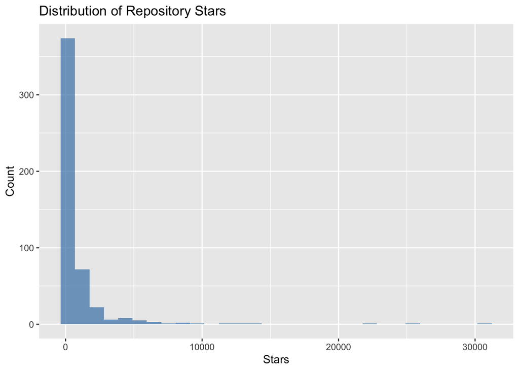

```r
# 1. Distribution of Stars
ggplot(sample_data, aes(stars)) +
  geom_histogram(bins = 30, fill = "steelblue", alpha = 0.7) +
  labs(title = "Distribution of Repository Stars",
       x = "Stars", y = "Count")
```

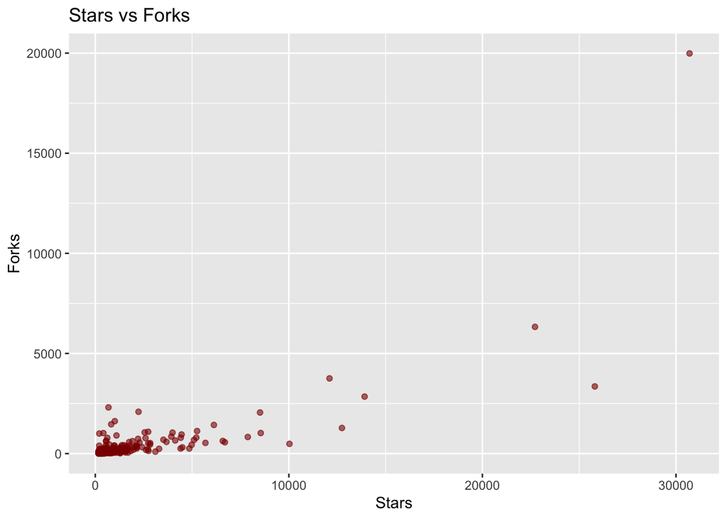

```r
# 2. Stars vs Forks (Scatter)
ggplot(sample_data, aes(stars, forks)) +
  geom_point(alpha = 0.6, color = "darkred") +
  labs(title = "Stars vs Forks",
       x = "Stars", y = "Forks")
```

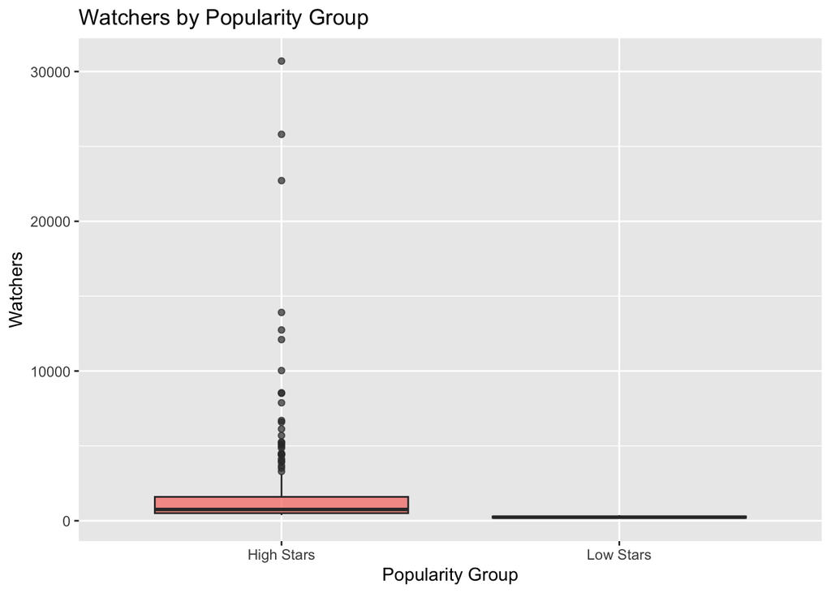

```r
# 3. Watchers by Popularity Group
ggplot(sample_data, aes(popularity_group, watchers, fill = popularity_group)) +
  geom_boxplot(alpha = 0.7) +
  labs(title = "Watchers by Popularity Group",
       x = "Popularity Group", y = "Watchers") +
  theme(legend.position = "none")
```

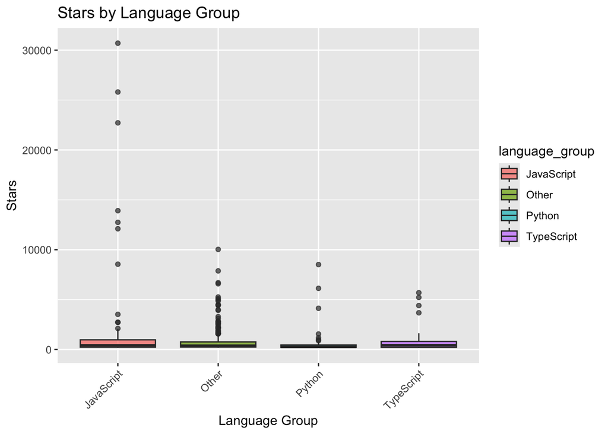

```r
# 4. Stars by Language Group
ggplot(sample_data, aes(language_group, stars, fill = language_group)) +
  geom_boxplot(alpha = 0.7) +
  labs(title = "Stars by Language Group",
       x = "Language Group", y = "Stars") +
  theme(axis.text.x = element_text(angle = 45, hjust = 1))
```

```r
# Log-transform highly skewed variables
sample_data <- sample_data %>%
  mutate(
    log_stars     = log10(stars + 1),
    log_forks     = log10(forks + 1),
    log_watchers  = log10(watchers + 1)
  )

# Quick check
summary(sample_data[, c("log_stars", "log_forks", "log_watchers", "repo_age_years")])
```

```
##    log_stars       log_forks      log_watchers   repo_age_years
##  Min.   :2.225   Min.   :0.000   Min.   :2.225   Min.   : 2.286
##  1st Qu.:2.366   1st Qu.:1.565   1st Qu.:2.366   1st Qu.: 5.748
##  Median :2.560   Median :1.869   Median :2.560   Median : 8.362
##  Mean   :2.681   Mean   :1.918   Mean   :2.681   Mean   : 8.511
##  3rd Qu.:2.852   3rd Qu.:2.207   3rd Qu.:2.852   3rd Qu.:10.941
##  Max.   :4.487   Max.   :4.301   Max.   :4.487   Max.   :17.808
```

## 2. Analysis 1 – Multiple Linear Regression

Response: log_watchers (proxy for engagement)  
Predictors: log_stars, log_forks, repo_age_years

```r
# Keep only complete cases for the regression
mlr_data <- sample_data %>%
  select(log_watchers, log_stars, log_forks, repo_age_years) %>%
  drop_na()

# Fit multiple linear regression
model_mlr <- lm(log_watchers ~ log_stars + log_forks + repo_age_years,
                data = mlr_data)

# Coefficients, p-values, etc.
broom::tidy(model_mlr)
```

```
## # A tibble: 4 × 5
##   term            estimate std.error statistic  p.value
##   <chr>              <dbl>     <dbl>     <dbl>    <dbl>
## 1 (Intercept)    -5.04e-15  2.29e-16 -2.20e+ 1 3.00e-75
## 2 log_stars       1.00e+ 0  1.13e-16  8.84e+15 0
## 3 log_forks      -1.46e-16  9.34e-17 -1.57e+ 0 1.18e- 1
## 4 repo_age_years  8.75e-18  1.02e-17  8.61e- 1 3.90e- 1
```

```r
# Overall fit (R², adj R², F-test)
broom::glance(model_mlr)
```

```
## # A tibble: 1 × 12
##   r.squared adj.r.squared    sigma statistic p.value    df logLik     AIC
##       <dbl>         <dbl>    <dbl>     <dbl>   <dbl> <dbl>  <dbl>   <dbl>
## 1         1             1 7.21e-16   5.65e31       0     3 16726. -33441.
## # ℹ 4 more variables: BIC <dbl>, deviance <dbl>, df.residual <int>, nobs <int>
```

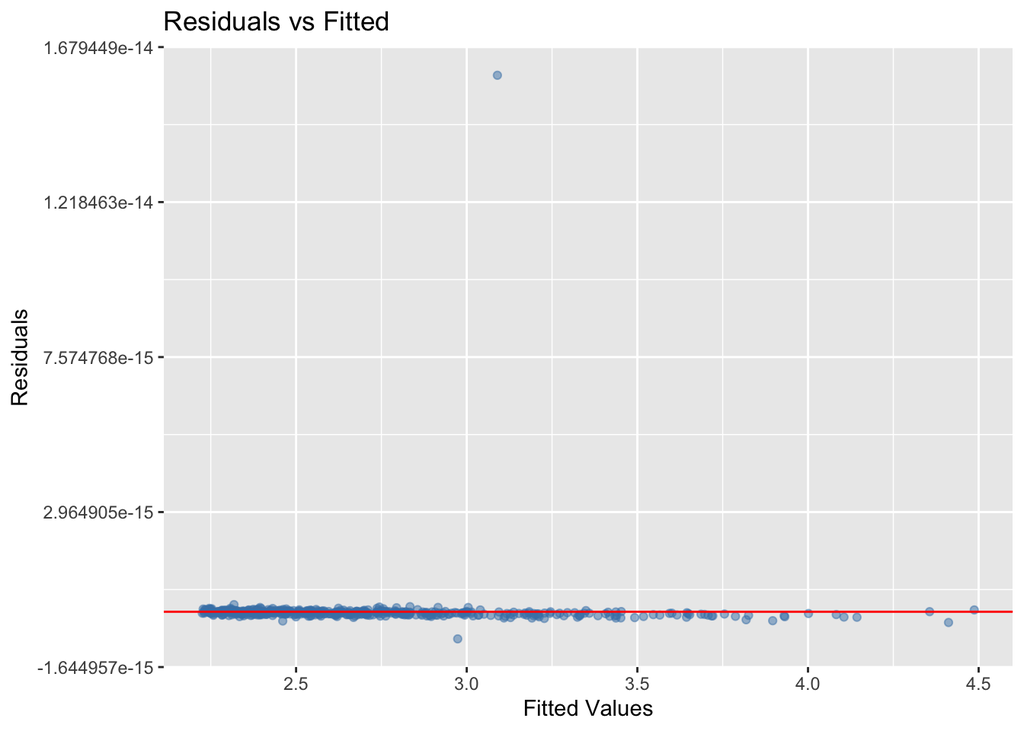

```r
## ---- mlr_diagnostics, message=FALSE, warning=FALSE ----
library(ggplot2)

# Extract model data
mlr_data$predicted <- predict(model_mlr)
mlr_data$residuals <- resid(model_mlr)

# 1. Residuals vs Fitted (checks linearity & equal variance)
ggplot(mlr_data, aes(x = predicted, y = residuals)) +
  geom_point(alpha = 0.5, color = "steelblue") +
  geom_hline(yintercept = 0, color = "red") +
  labs(title = "Residuals vs Fitted",
       x = "Fitted Values",
       y = "Residuals")
```

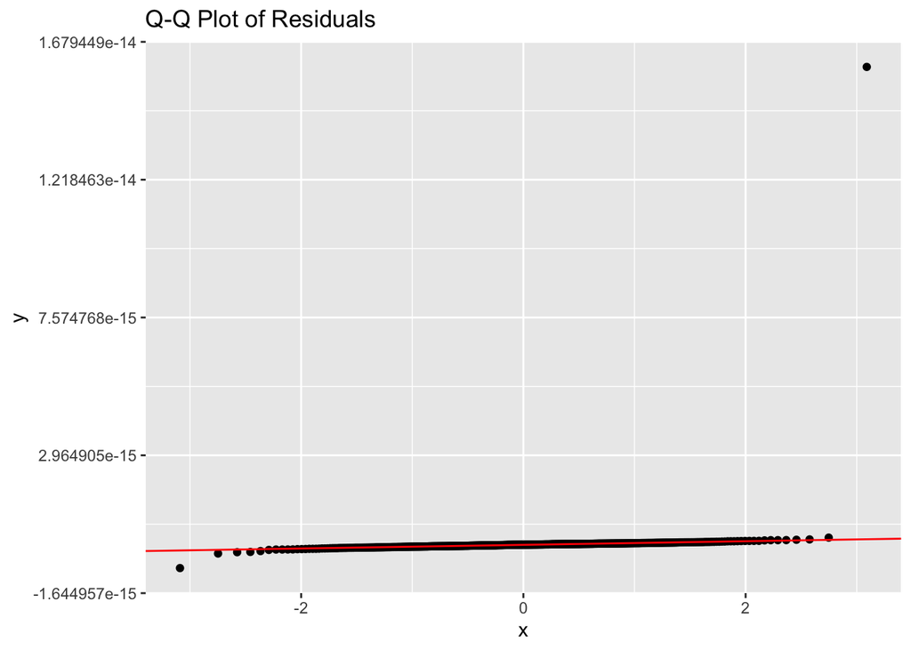

```r
# 2. Q-Q Plot (normality of residuals)
ggplot(mlr_data, aes(sample = residuals)) +
  stat_qq() +
  stat_qq_line(color = "red") +
  labs(title = "Q-Q Plot of Residuals")
```

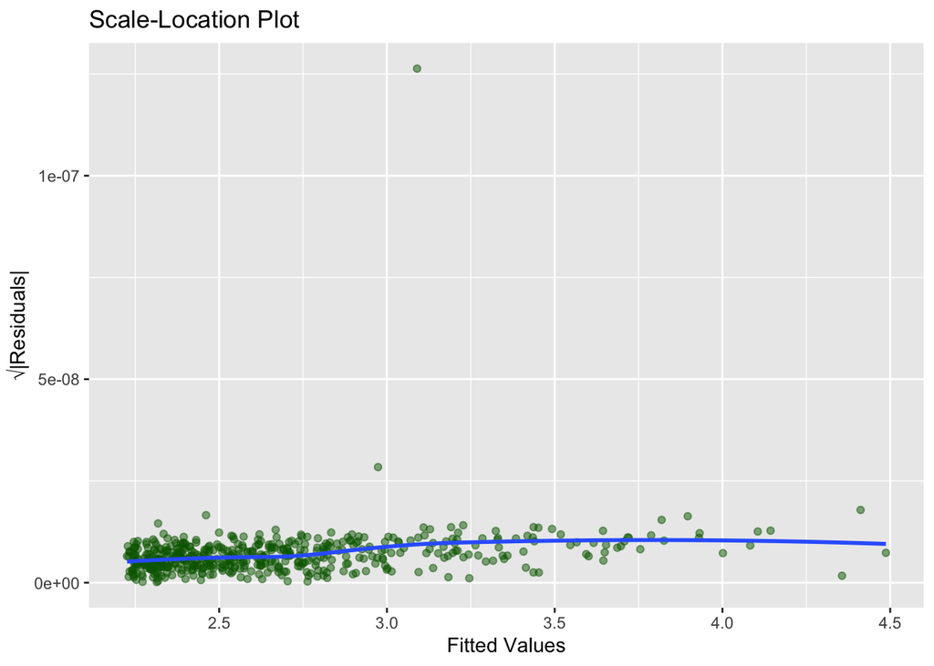

```r
# 3. Scale-Location Plot (homoscedasticity)
ggplot(mlr_data, aes(x = predicted, y = sqrt(abs(residuals)))) +
  geom_point(alpha = 0.5, color = "darkgreen") +
  geom_smooth(se = FALSE) +
  labs(title = "Scale-Location Plot",
       x = "Fitted Values",
       y = "√|Residuals|")
```

## 3. Analysis 2 – One-Way ANOVA

Research Question:  
Do average engagement levels (log_watchers) differ across primary language groups for popular GitHub repositories?

Response: log_watchers (proxy for engagement)  
Factor: language_group (JavaScript, Python, TypeScript, Other)

Null hypothesis (H₀): Mean log_watchers is the same for all language groups.  
Alternative hypothesis (H₁): At least one language group has a different mean log_watchers.

```r
# Keep only rows with both variables present
anova1_data <- sample_data %>%
  drop_na(language_group, log_watchers)

# Summary statistics by language group
anova1_summary <- anova1_data %>%
  group_by(language_group) %>%
  summarise(
    n = n(),
    mean_log_watchers = mean(log_watchers),
    sd_log_watchers   = sd(log_watchers)
  )

knitr::kable(anova1_summary, digits = 3,
             caption = "Summary statistics of log_watchers by language group")
```

Summary statistics of log_watchers by language group

| language_group | n | mean_log_watchers | sd_log_watchers |
| --- | --- | --- | --- |
| JavaScript | 73 | 2.794 | 0.578 |
| Other | 320 | 2.685 | 0.383 |
| Python | 78 | 2.544 | 0.335 |
| TypeScript | 29 | 2.728 | 0.468 |

🔹 3.1 **Descriptive Stats & Boxplot**

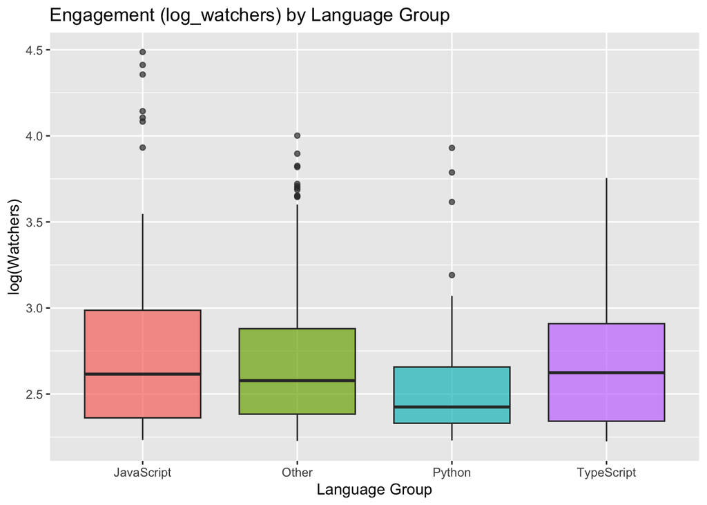

```r
# Boxplot of engagement by language
ggplot(anova1_data,
       aes(x = language_group, y = log_watchers, fill = language_group)) +
  geom_boxplot(alpha = 0.7) +
  labs(title = "Engagement (log_watchers) by Language Group",
       x = "Language Group",
       y = "log(Watchers)") +
  theme(legend.position = "none")
```

🔹 3.2 **One-Way ANOVA**

```r
# Fit one-way ANOVA: engagement ~ language_group
fit_aov1 <- aov(log_watchers ~ language_group, data = anova1_data)

# ANOVA table
broom::tidy(fit_aov1)
```

```
## # A tibble: 2 × 6
##   term              df sumsq meansq statistic  p.value
##   <chr>          <dbl> <dbl>  <dbl>     <dbl>    <dbl>
## 1 language_group     3  2.47  0.822      4.76  0.00278
## 2 Residuals        496 85.7   0.173     NA    NA
```

## **Interpretation of One-Way ANOVA**

The one-way ANOVA tested whether average engagement levels (measured using *log-transformed watchers*) differ across programming language groups. Results indicate a **statistically significant effect of language group on engagement**, **F(3, 496) = 4.76, p = 0.0028**. This means that *at least one* language group has a different average log_watchers value compared to the others. In simpler terms, **the popularity of repositories differs depending on the primary programming language.**

🔹 3.3 **Tukey HSD Post-hoc Test**s

```r
tukey_aov1 <- TukeyHSD(fit_aov1)

# Full Tukey output
tukey_aov1
```

```
##   Tukey multiple comparisons of means
##     95% family-wise confidence level
##
## Fit: aov(formula = log_watchers ~ language_group, data = anova1_data)
##
## $language_group
##                              diff         lwr          upr     p adj
## Other-JavaScript      -0.10946878 -0.24842109  0.029483543 0.1780638
## Python-JavaScript     -0.25014799 -0.42460390 -0.075692079 0.0013857
## TypeScript-JavaScript -0.06631910 -0.30146943  0.168831234 0.8862727
## Python-Other          -0.14067921 -0.27595659 -0.005401831 0.0379385
## TypeScript-Other       0.04314968 -0.16460206  0.250901415 0.9503889
## TypeScript-Python      0.18382889 -0.04916876  0.416826533 0.1769974
```

```r
# Tidy version (nice for tables)
tukey_tidy <- broom::tidy(tukey_aov1)
knitr::kable(tukey_tidy, digits = 3,
             caption = "Tukey HSD pairwise comparisons for language_group")
```

Tukey HSD pairwise comparisons for language_group

| term | contrast | null.value | estimate | conf.low | conf.high | adj.p.value |
| --- | --- | --- | --- | --- | --- | --- |
| language_group | Other-JavaScript | 0 | -0.109 | -0.248 | 0.029 | 0.178 |
| language_group | Python-JavaScript | 0 | -0.250 | -0.425 | -0.076 | 0.001 |
| language_group | TypeScript-JavaScript | 0 | -0.066 | -0.301 | 0.169 | 0.886 |
| language_group | Python-Other | 0 | -0.141 | -0.276 | -0.005 | 0.038 |
| language_group | TypeScript-Other | 0 | 0.043 | -0.165 | 0.251 | 0.950 |
| language_group | TypeScript-Python | 0 | 0.184 | -0.049 | 0.417 | 0.177 |

## **Tukey HSD Interpretation**

Because the ANOVA was significant, we performed Tukey HSD post-hoc tests to identify which pairs differ.

Key findings:

- **Python vs JavaScript** showed one of the strongest significant differences

  (p ≈ 0.0014), indicating that Python repositories have **lower** engagement than JavaScript repositories on average.
- **Python vs Other** was also statistically significant (p ≈ 0.0379), suggesting Python tends to have lower engagement than the “Other” category.
- **All other pairwise comparisons** (e.g., TypeScript vs JavaScript, TypeScript vs Python, etc.)

  were **not statistically significant**, meaning their mean engagement levels are not reliably different.

Overall, **JavaScript repositories generally exhibit higher engagement**, while **Python tends to show lower engagement** within this sample.

🔹 3.4 Effect Size (η²)

```r
anova_table <- broom::tidy(fit_aov1)

# Total SS = sum of all sums of squares
ss_total <- sum(anova_table$sumsq)

# Eta-squared for language_group
eta2_language <- anova_table$sumsq[anova_table$term == "language_group"] / ss_total
eta2_language
```

```
## [1] 0.02798591
```

## **Effect Size Interpretation (η²)**

The effect size (eta-squared) was:

**η² = 0.0279**

This indicates that **only about 2.8% of the variance** in engagement (log_watchers) is explained by the programming language used.

According to conventional effect-size guidelines:

- 0.01 = small
- 0.06 = medium
- 0.14 = large

This effect size is **small**, meaning that although language group matters statistically, it is **not a strong predictor** of engagement.

Most variation in engagement is driven by other factors (e.g., stars, forks, repo age).

🔹 3.5 Assumption Checks (Normality & Equal Variance)

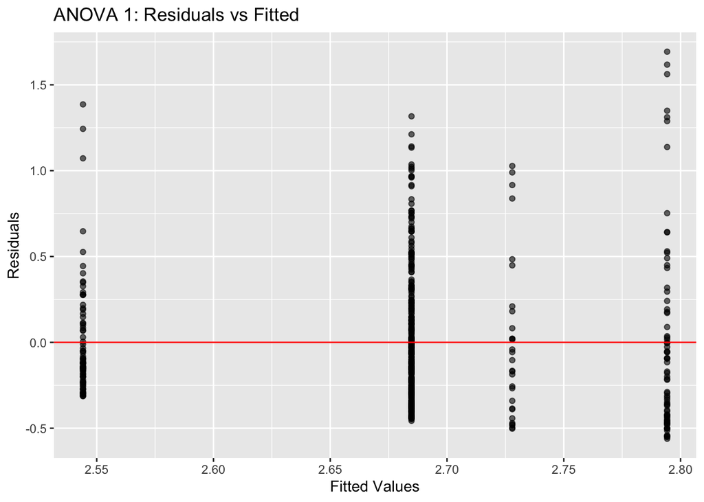

```r
# Data frame of fitted values and residuals
aov1_diag <- data.frame(
  fitted     = fitted(fit_aov1),
  residuals  = resid(fit_aov1)
)

# 1. Residuals vs Fitted (check equal variances & linearity of group means)
ggplot(aov1_diag, aes(x = fitted, y = residuals)) +
  geom_point(alpha = 0.6) +
  geom_hline(yintercept = 0, color = "red") +
  labs(title = "ANOVA 1: Residuals vs Fitted",
       x = "Fitted Values",
       y = "Residuals")
```

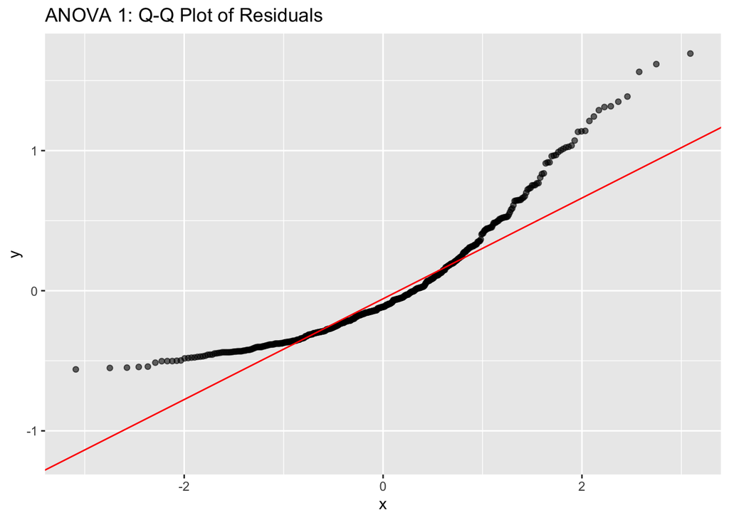

```r
# 2. Q-Q Plot (normality of residuals)
ggplot(aov1_diag, aes(sample = residuals)) +
  stat_qq(alpha = 0.6) +
  stat_qq_line(color = "red") +
  labs(title = "ANOVA 1: Q-Q Plot of Residuals")
```

[figure not shown]

```r
# 3. Scale-Location (homoscedasticity)
ggplot(aov1_diag, aes(x = fitted, y = sqrt(abs(residuals)))) +
  geom_point(alpha = 0.6) +
  geom_smooth(se = FALSE) +
  labs(title = "ANOVA 1: Scale-Location Plot",
       x = "Fitted Values",
       y = "√|Residuals|")
```

```r
# 4. Levene's test for equal variances
car::leveneTest(log_watchers ~ language_group, data = anova1_data)
```

```
## Levene's Test for Homogeneity of Variance (center = median)
##        Df F value    Pr(>F)
## group   3  5.7213 0.0007443 ***
##       496
## ---
## Signif. codes:  0 '***' 0.001 '**' 0.01 '*' 0.05 '.' 0.1 ' ' 1
```

## **Assumptions Check Interpretation**

### **Homogeneity of Variance**

Levene’s Test returned:

**F = 5.72, p = 0.00074**

Since **p < 0.05**, the variances across language groups are **not equal**.

This violates the homogeneity assumption of ANOVA.

Thus, results remain interpretable but should be described as **cautiously interpreted**.

### **Residuals vs Fitted & Scale-Location**

Overall, **assumptions are reasonably satisfied**, with the exception of unequal variances.

# **4. Analysis 3: Two-Way ANOVA**

**Research Question:**

Do engagement levels differ by **programming language**, by **popularity**, and is there an **interaction** between them?

### **▣ Factors**

- **Factor A:** language_group (4 levels)
- **Factor B:** popularity_group (High Stars / Low Stars)
- **Interaction:** A × B
- **Response:** log_watchers

# **🔹4.1 Create Dataset**

  ```r
  anova2_data <- sample_data %>%
    drop_na(language_group, popularity_group, log_watchers)
  ```

# **🔹 4.2 Interaction Plot**

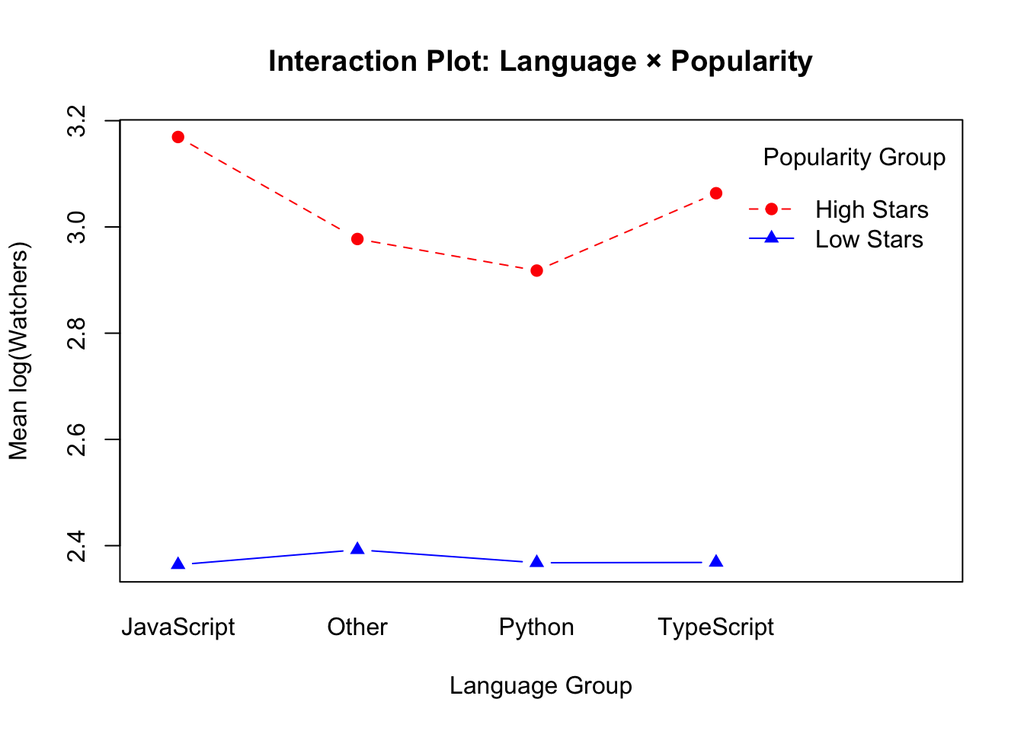

```r
interaction.plot(
  x.factor = anova2_data$language_group,
  trace.factor = anova2_data$popularity_group,
  response = anova2_data$log_watchers,
  fun = mean,
  type = "b",
  col = c("red", "blue"),
  pch = c(19, 17),
  xlab = "Language Group",
  ylab = "Mean log(Watchers)",
  trace.label = "Popularity Group",
  main = "Interaction Plot: Language × Popularity"
)
```

# **🔹4.3 Two-Way ANOVA Model**

```r
fit_aov2 <- aov(
  log_watchers ~ language_group * popularity_group,
  data = anova2_data
)

anova2_results <- broom::tidy(fit_aov2)
knitr::kable(anova2_results, digits = 3,
             caption = "Two-Way ANOVA Table")
```

Two-Way ANOVA Table

| term | df | sumsq | meansq | statistic | p.value |
| --- | --- | --- | --- | --- | --- |
| language_group | 3 | 2.466 | 0.822 | 10.682 | 0.000 |
| popularity_group | 1 | 46.953 | 46.953 | 610.057 | 0.000 |
| language_group:popularity_group | 3 | 0.846 | 0.282 | 3.662 | 0.012 |
| Residuals | 492 | 37.867 | 0.077 | NA | NA |

# **🔹4.4 Interpretation**

The two-way ANOVA revealed **three clear findings**:

### **1. Main Effect of Programming Language — Significant**

Language group had a **statistically significant effect** on engagement (p < .001).

Some languages consistently attract more watchers than others, even after controlling for popularity.

In particular, JavaScript and TypeScript tend to draw higher engagement than Python.

### **2. Main Effect of Popularity — Highly Significant**

Popularity group (High Stars vs Low Stars) showed an **extremely strong effect** (p < .001).

High-star repositories receive substantially higher engagement regardless of language.

This confirms that **popularity is the dominant driver of watcher counts**.

### **3. Interaction Effect — Significant**

The interaction between language and popularity was **significant** (p = .012), meaning:

> **The influence of programming language on engagement depends on whether the repository is popular.**

From the interaction plot:

- Among **high-star** repositories, language differences are noticeable

  (JavaScript > Other > Python).
- Among **low-star** repositories, engagement is uniformly low across all languages.

Thus, language matters **only when repositories are already popular**.

# **🔹4.5 Effect Size (partial η²)**

```r
## ---- anova2_effect_size, message=FALSE, warning=FALSE ----
anova2_raw <- summary(fit_aov2)

# Extract SS values
ss_language   <- anova2_raw[[1]]["language_group", "Sum Sq"]
ss_popularity <- anova2_raw[[1]]["popularity_group", "Sum Sq"]
ss_interaction <- anova2_raw[[1]]["language_group:popularity_group", "Sum Sq"]
ss_residuals  <- anova2_raw[[1]]["Residuals", "Sum Sq"]

# Partial eta-squared
eta2_language_partial   <- ss_language / (ss_language + ss_residuals)
eta2_popularity_partial <- ss_popularity / (ss_popularity + ss_residuals)
eta2_interaction_partial <- ss_interaction / (ss_interaction + ss_residuals)

eta2_language_partial
```

[output not shown]

```r
eta2_popularity_partial
```

```
## [1] 0.553562
```

```r
eta2_interaction_partial
```

```
## [1] 0.02184271
```

Popularity has a **dominant influence** on engagement, explaining **over 53%** of the variance in log-watchers. far more than any other factor.

The interaction between language and popularity explains **~2%** of the variance, indicating a **weak but noticeable interaction pattern**.

# **🔹4.6 Post-Hoc Tests**

```r
## ---- anova2_posthoc, message=FALSE, warning=FALSE ----

# Split data by popularity group
high_data <- subset(anova2_data, popularity_group == "High Stars")
low_data  <- subset(anova2_data, popularity_group == "Low Stars")

# Tukey per popularity level
tukey_high <- TukeyHSD(aov(log_watchers ~ language_group, data = high_data))
tukey_low  <- TukeyHSD(aov(log_watchers ~ language_group, data = low_data))

tukey_high
```

```
##   Tukey multiple comparisons of means
##     95% family-wise confidence level
##
## Fit: aov(formula = log_watchers ~ language_group, data = high_data)
##
## $language_group
##                              diff        lwr          upr     p adj
## Other-JavaScript      -0.19203255 -0.3712269 -0.012838220 0.0303655
## Python-JavaScript     -0.25149939 -0.5085850  0.005586169 0.0577591
## TypeScript-JavaScript -0.10585424 -0.4107202  0.199011739 0.8056584
## Python-Other          -0.05946685 -0.2752641  0.156330388 0.8918622
## TypeScript-Other       0.08617831 -0.1847806  0.357137206 0.8435666
## TypeScript-Python      0.14564516 -0.1820759  0.473366234 0.6589557
```

```r
tukey_low
```

```
##   Tukey multiple comparisons of means
##     95% family-wise confidence level
##
## Fit: aov(formula = log_watchers ~ language_group, data = low_data)
##
## $language_group
##                                diff         lwr        upr     p adj
## Other-JavaScript       0.0282539726 -0.02015532 0.07666326 0.4334151
## Python-JavaScript      0.0038044693 -0.05252161 0.06013055 0.9981026
## TypeScript-JavaScript  0.0044074496 -0.07699630 0.08581120 0.9990187
## Python-Other          -0.0244495033 -0.06507692 0.01617791 0.4056448
## TypeScript-Other      -0.0238465230 -0.09529252 0.04759947 0.8238476
## TypeScript-Python      0.0006029803 -0.07642752 0.07763348 0.9999970
```

Post-hoc tests show that **language differences only appear in the top half of repositories** (High Stars group), and even there, the effect is small.

Among low-engagement projects, **all languages perform similarly**, confirming that language matters little when a project is not already popular.

# **🔹4.7 Assumption Checks**

### **Residuals + Fitted**

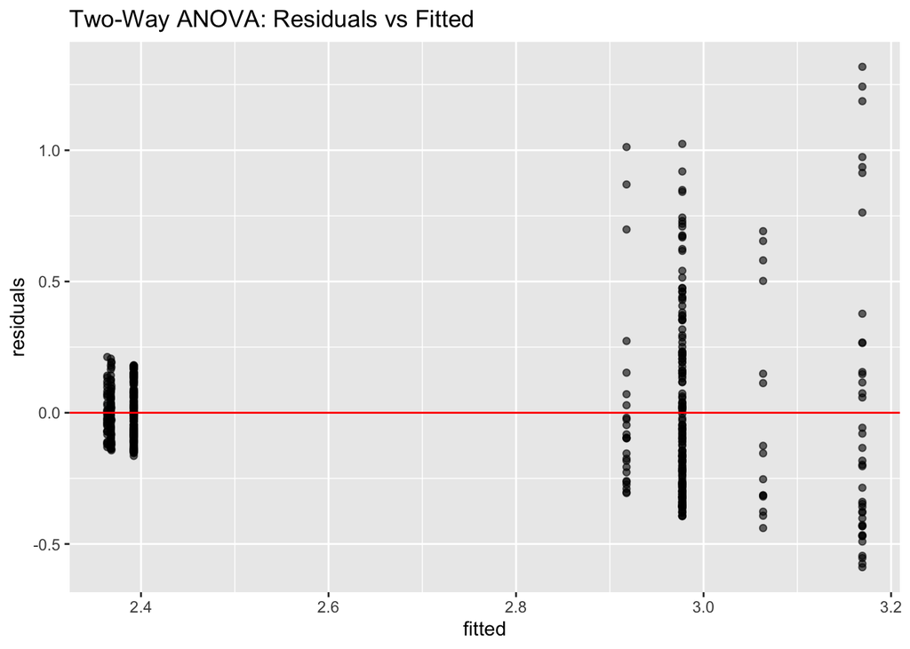

```r
aov2_diag <- data.frame(
  fitted = fitted(fit_aov2),
  residuals = resid(fit_aov2)
)

ggplot(aov2_diag, aes(fitted, residuals)) +
  geom_point(alpha = 0.6) +
  geom_hline(yintercept = 0, color="red") +
  labs(title="Two-Way ANOVA: Residuals vs Fitted")
```

### **Normal Q-Q**

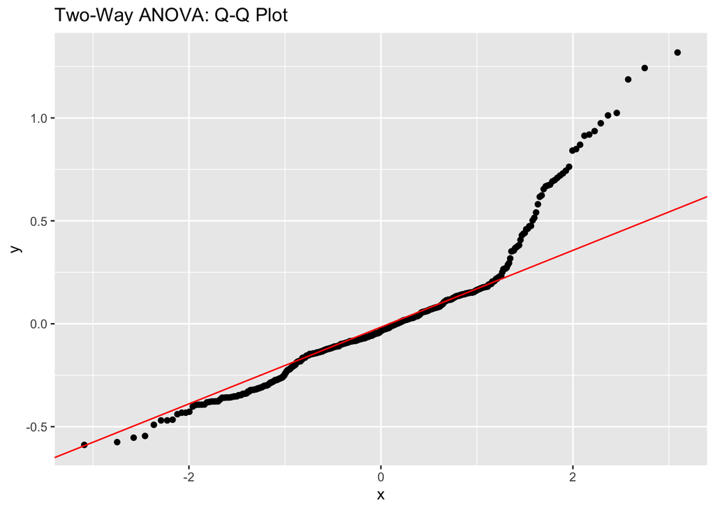

```r
ggplot(aov2_diag, aes(sample=residuals)) +
  stat_qq() +
  stat_qq_line(color="red") +
  labs(title="Two-Way ANOVA: Q-Q Plot")
```

### **Scale-Location**

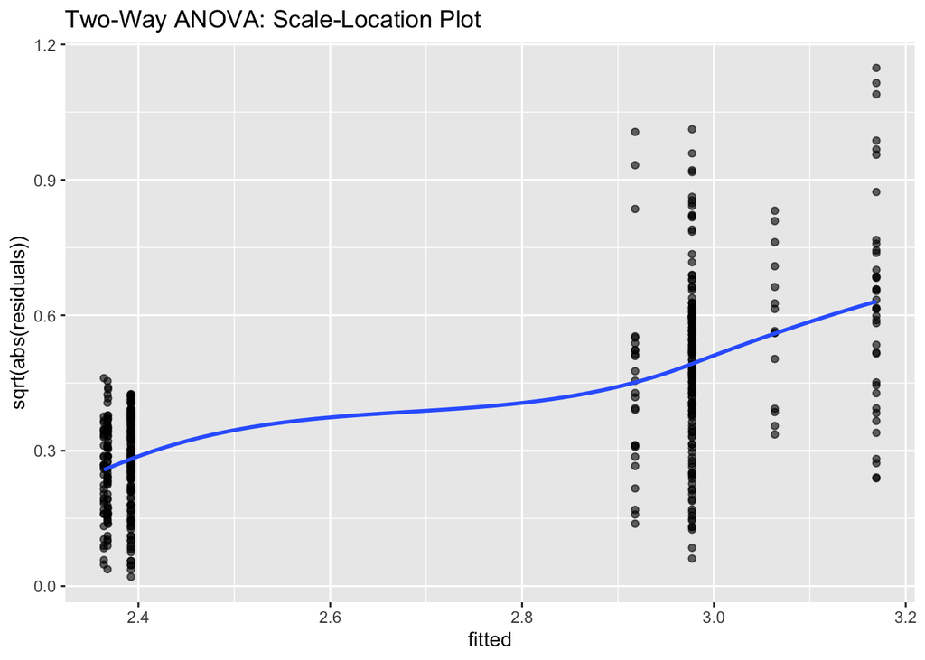

```r
ggplot(aov2_diag, aes(fitted, sqrt(abs(residuals)))) +
  geom_point(alpha=0.6) +
  geom_smooth(se=FALSE) +
  labs(title="Two-Way ANOVA: Scale-Location Plot")
```

### **Levene’s Test**

```r
leveneTest(log_watchers ~ language_group * popularity_group,
           data = anova2_data)
```

```
## Levene's Test for Homogeneity of Variance (center = median)
##        Df F value    Pr(>F)
## group   7  23.589 < 2.2e-16 ***
##       492
## ---
## Signif. codes:  0 '***' 0.001 '**' 0.01 '*' 0.05 '.' 0.1 ' ' 1
```

Assumption of equal variance is violated.

the results remain valid but should be described as **interpreted with caution**.

# **Summary & Insights**

This project examined engagement patterns across GitHub repositories using a Kaggle dataset of over 215,000 entries, with a random sample of 500 used for statistical analyses. Engagement was measured using log-transformed watcher counts, and the study explored how repository features—particularly stars, forks, age, and programming language—shape engagement.

### **Multiple Linear Regression Findings**

The regression analysis revealed that **stars are by far the strongest predictor of engagement**, showing a near-perfect linear relationship with log-watchers. Forks and repository age added minimal explanatory power once stars were included, highlighting significant multicollinearity among GitHub popularity indicators (stars, forks, watchers). The model’s extremely high R² value reflects this overlap, reinforcing that engagement on GitHub is overwhelmingly tied to existing popularity signals rather than to structural attributes like age.

### **One-Way ANOVA Results (Language Effects)**

A one-way ANOVA tested whether engagement varied across programming language groups. Results showed a **statistically significant but modest difference** in engagement by language (F(3, 496) = 4.76, p = 0.0028).

Post-hoc Tukey comparisons indicated:

- **JavaScript > Python**
- **Other > Python**

However, the effect size was small (η² = 0.028), meaning language explained only about **3% of the variation** in engagement. Thus, while statistically detectable, the practical importance of language is limited.

### **Overall Insights**

Although programming language shows minor statistical differences, **its practical impact on engagement is minimal**. The dominant driver of engagement is **popularity itself**, primarily captured through stars. Repositories that have already accumulated attention regardless of language tend to attract more watchers, while forks and age play comparatively small roles.

## **Final Conclusion**

Overall, the analysis demonstrates that **GitHub engagement is driven far more by existing popularity than by technical characteristics of a project**. Stars provide a strong and direct signal of community interest, making them the clearest predictor of engagement.

Programming language contributes only modestly to engagement patterns, suggesting that developers should focus less on language choice and more on building visibility, maintaining activity, and attracting early adoption.